# ggplot2: The basics

Adam Wespiser

November 4, 2014

## Intro

This course includes both example code and exercises for you to learn the concepts.  
Before starting, please make sure the following libraries are loaded. If you cannot load a  
library, you probably don’t have it, and should use the `install.packages()` function to load them.

## ggplot2 basics

ggplot2 was devloped by Hadley Wickham, a notable R programmer and contributor to Rstudio.  
The project stable, and should be available for the long term.  
Use http://docs.ggplot2.org/current/ as a reference.  
http://www.r-bloggers.com/ is a collection of recent articles on R.  
To save a plot, use `ggsave`

```r
source("http://bib.umassmed.edu/~wespisea/rCourse/adamGgplot2/answers.R")
```

```
## [1] "Answers have successfully loaded"
```

```r
library(ggplot2)
library(plyr)
library(grid)
library(reshape2)
library(gridExtra)
library(MASS)
library(HistData)
```

Load the datasets…

## Scatter Plots

To create a scatter plot using qplot you would use:

```r
qplot(data=iris,x=Sepal.Width,y=Sepal.Length,geom="point")
```

For ggplot2, the command is:

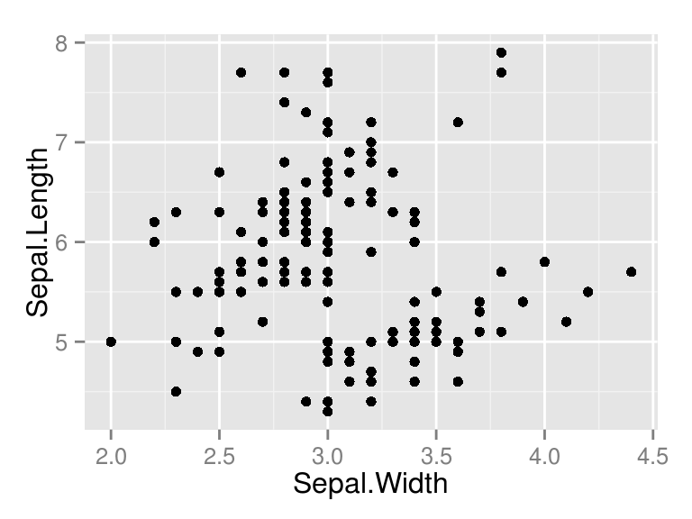

```r
ggplot(iris,aes(x=Sepal.Width,y=Sepal.Length)) + geom_point()
```

### Question 1

Use the women dataset to plot average heights and weights for american women.  
First, check the contents of the dataset using `str(women)` and use `help(women)` to learn about the data. Check the answer by `cat(answer1)`.

## Aesthetic Mappings

we can map: color, shape to data.frames or arbritrary values

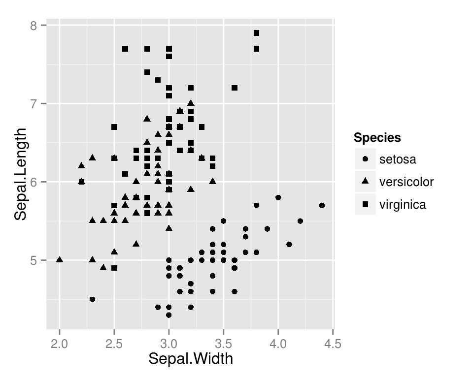

```r
ggplot(iris,aes(x=Sepal.Width,y=Sepal.Length,shape=Species)) + geom_point()
```

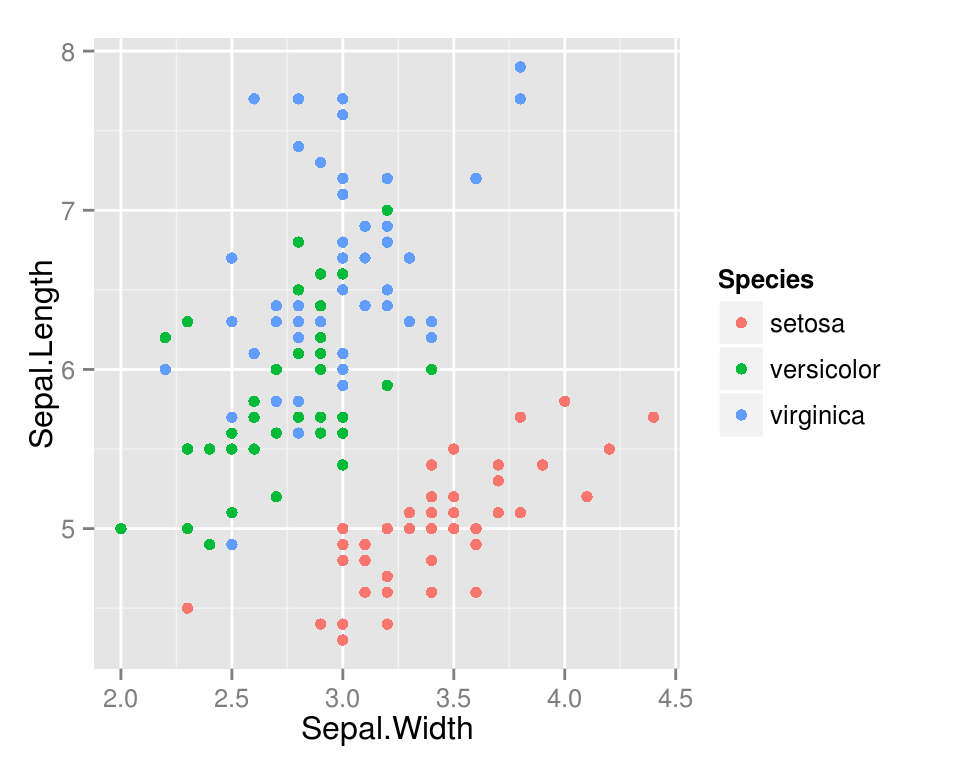

```r
ggplot(iris,aes(x=Sepal.Width,y=Sepal.Length,color=Species)) + geom_point()
```

### Question 2

Using the `birthwt` dataset, what is the distribution of age vs. weight?  
By coloring the points, is low birth weight associated with either variable?  
Check the answer by `cat(answer2)`.

#### Set aesthetics to fixed values:

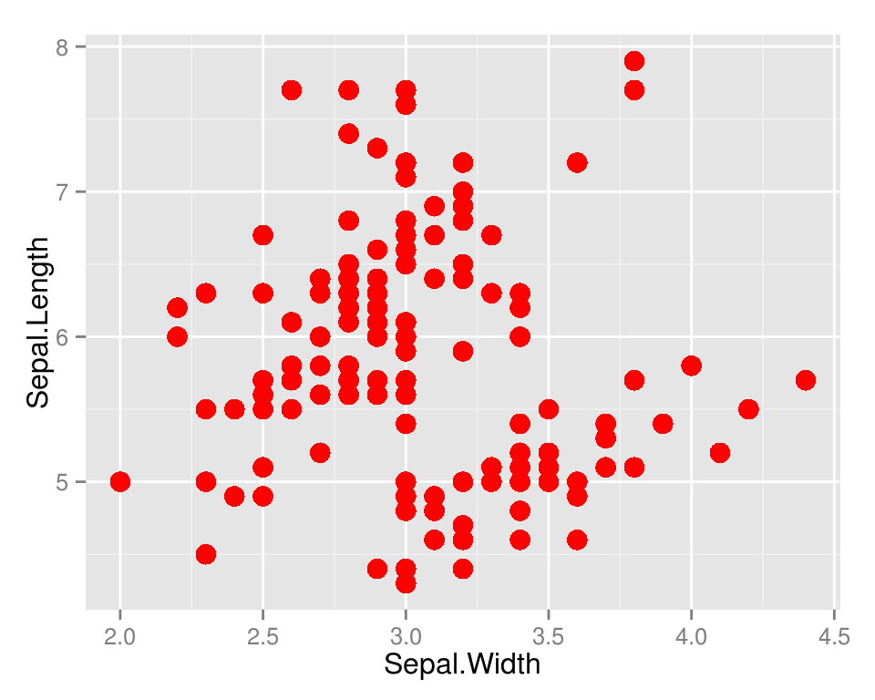

```r
ggplot(iris,aes(x=Sepal.Width,y=Sepal.Length)) + geom_point(color="red",size=4)
```

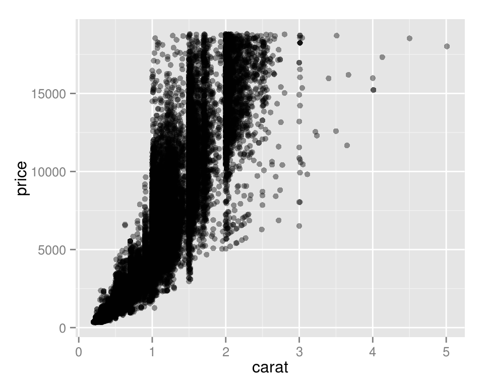

```r
ggplot(diamonds,aes(x=carat,y=price))+ geom_point(alpha=I(0.4))
```

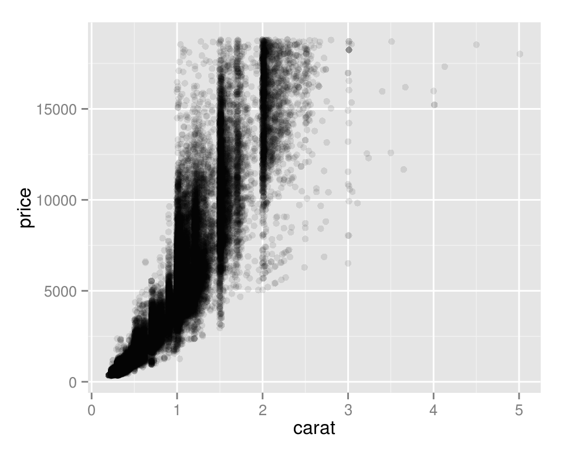

```r
ggplot(diamonds,aes(x=carat,y=price))+ geom_point(alpha=I(0.1))
```

#### Layered geoms

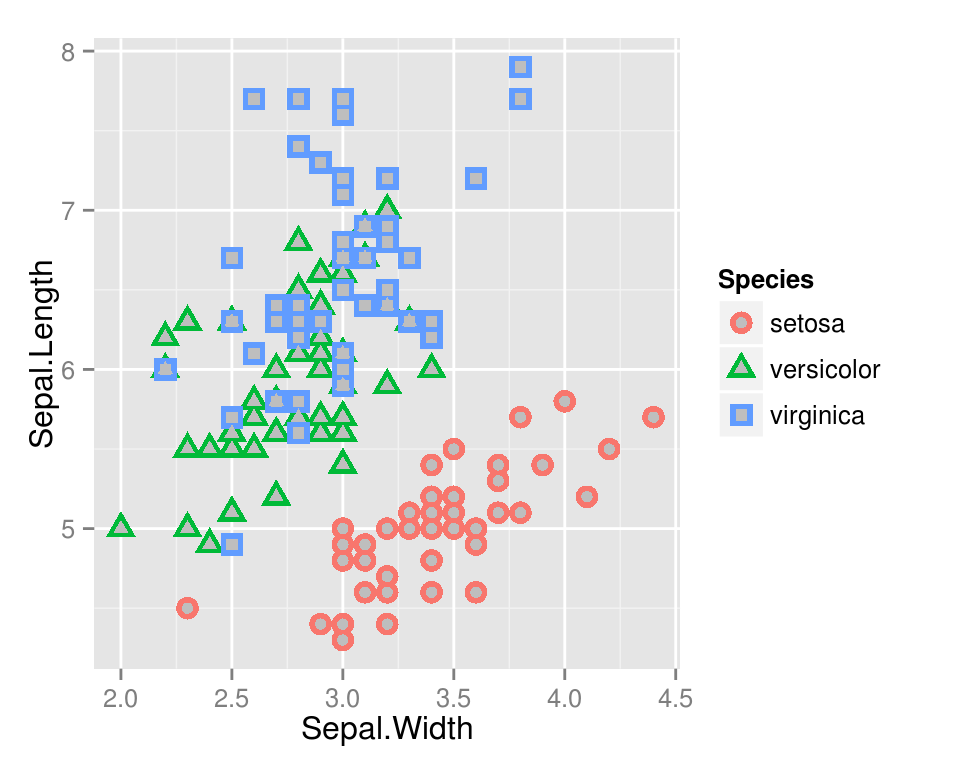

```r
ggplot(iris,aes(x=Sepal.Width,y=Sepal.Length,color=Species,shape=Species)) +
  geom_point(size=4) +
  geom_point(size=2,color="grey")
```

## Line Plot

note, the aesthetic mappings work the same

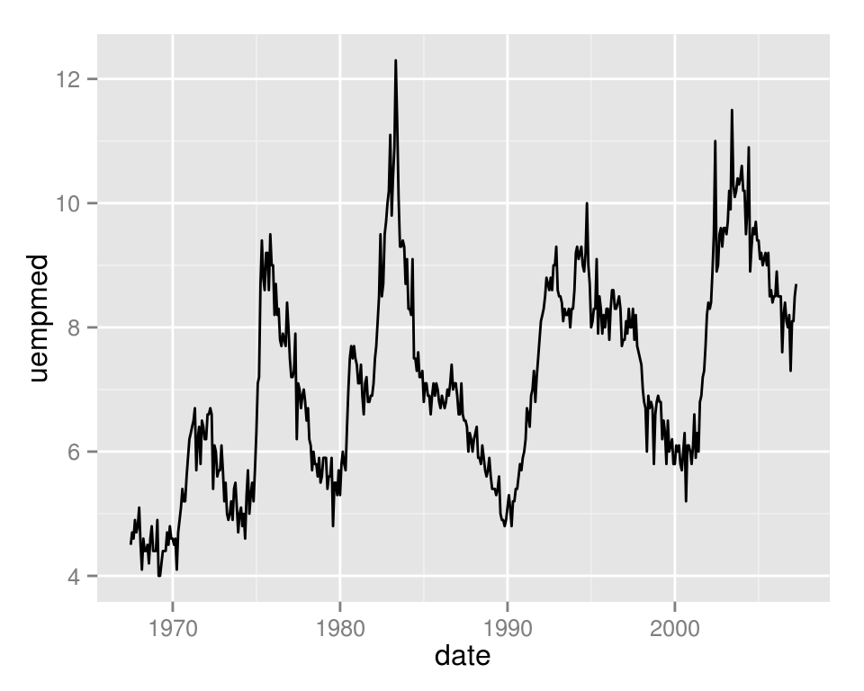

```r
ggplot(economics,aes(x=date,y=uempmed))+geom_line()
```

### Question 3

plot the number of Typhoid Fever deaths per year using the epi dataset. If you are stuck, take a look at `cat(hint3)` and `cat(hint3.1)` for the data transforms. Check the answer by `cat(answer3)`.

#### Add labels and a title:

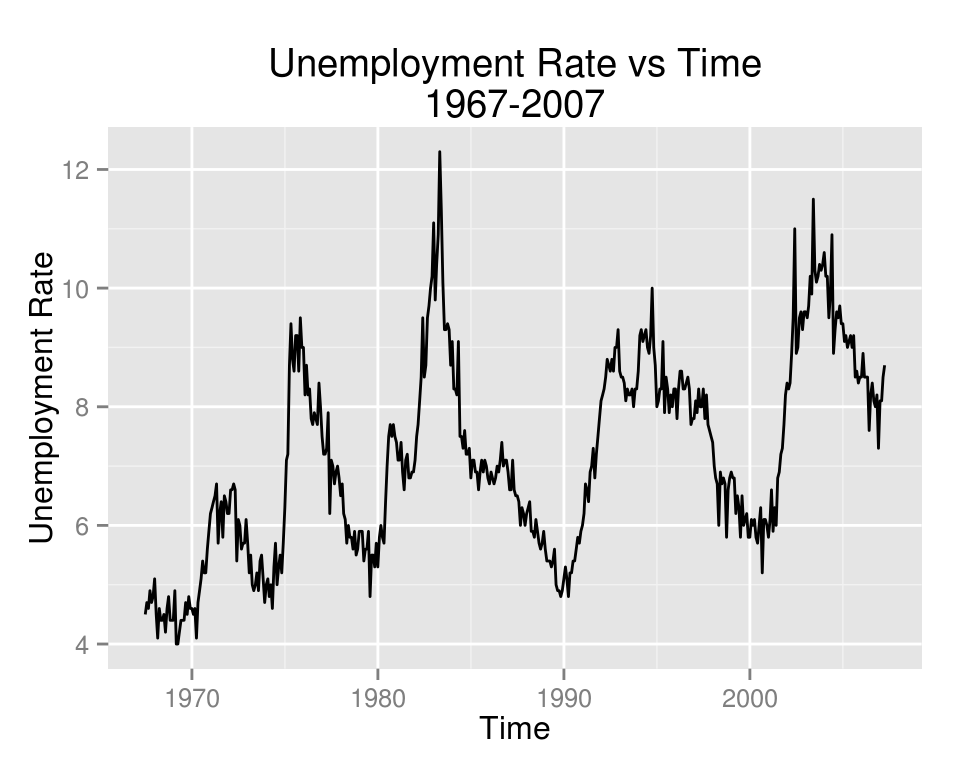

```r
ggplot(economics,aes(x=date,y=uempmed))+ geom_line() +
  xlab("Time") +
  ylab("Unemployment Rate") +
  ggtitle("Unemployment Rate vs Time\n1967-2007")
```

### Question 4

Add labels and a title to the previous plot. Example solution: `cat(answer4)`.

## Bar Plot

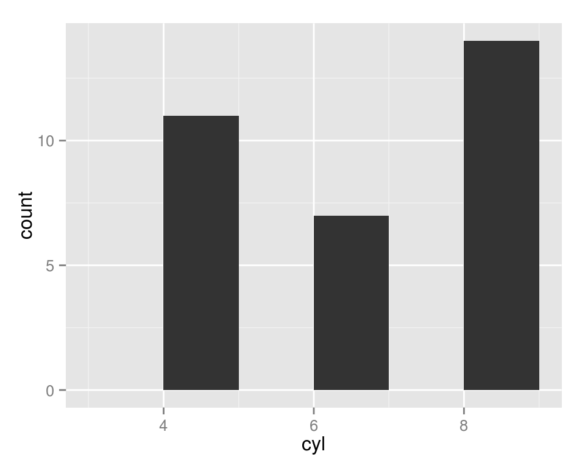

```r
ggplot(mtcars,aes(x=cyl))+geom_bar(binwidth=1)
```

#### use factor instead of numerical datatypes

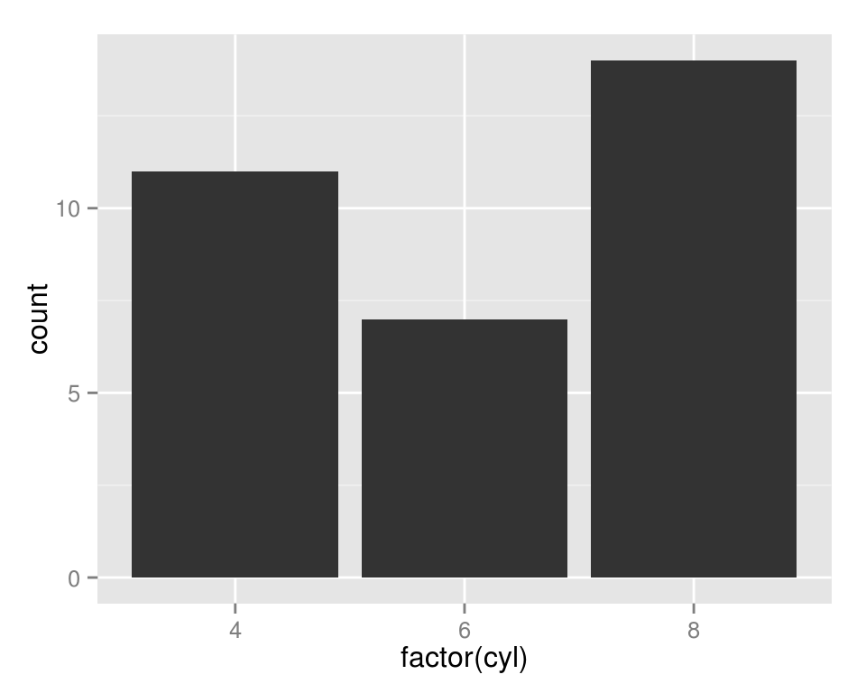

```r
ggplot(mtcars,aes(x=factor(cyl)))+geom_bar()
```

#### color the bars by type

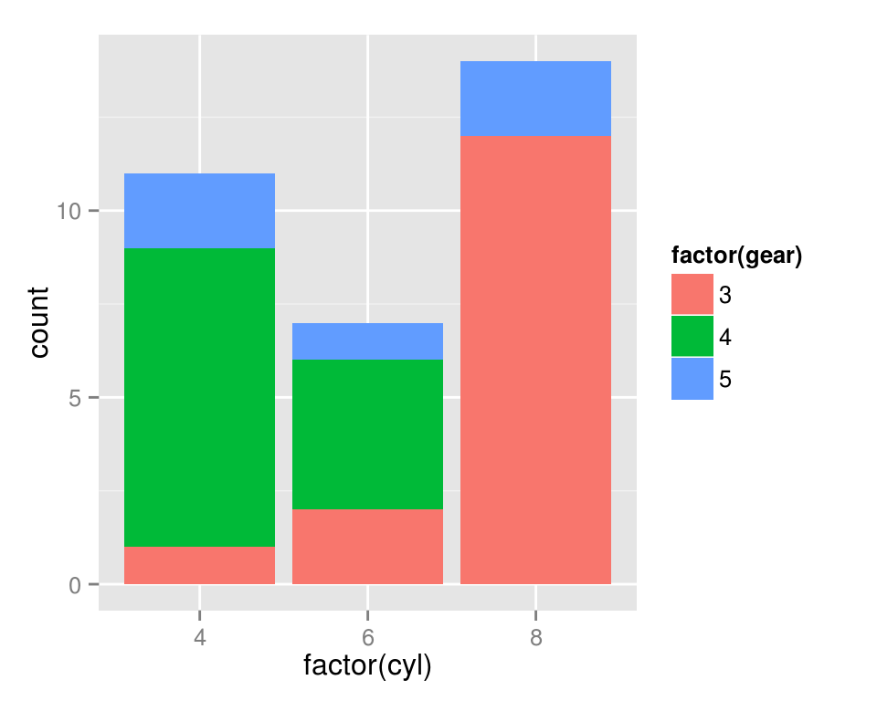

```r
ggplot(mtcars,aes(x=factor(cyl),fill=factor(gear)))+geom_bar()
```

#### another, better example:

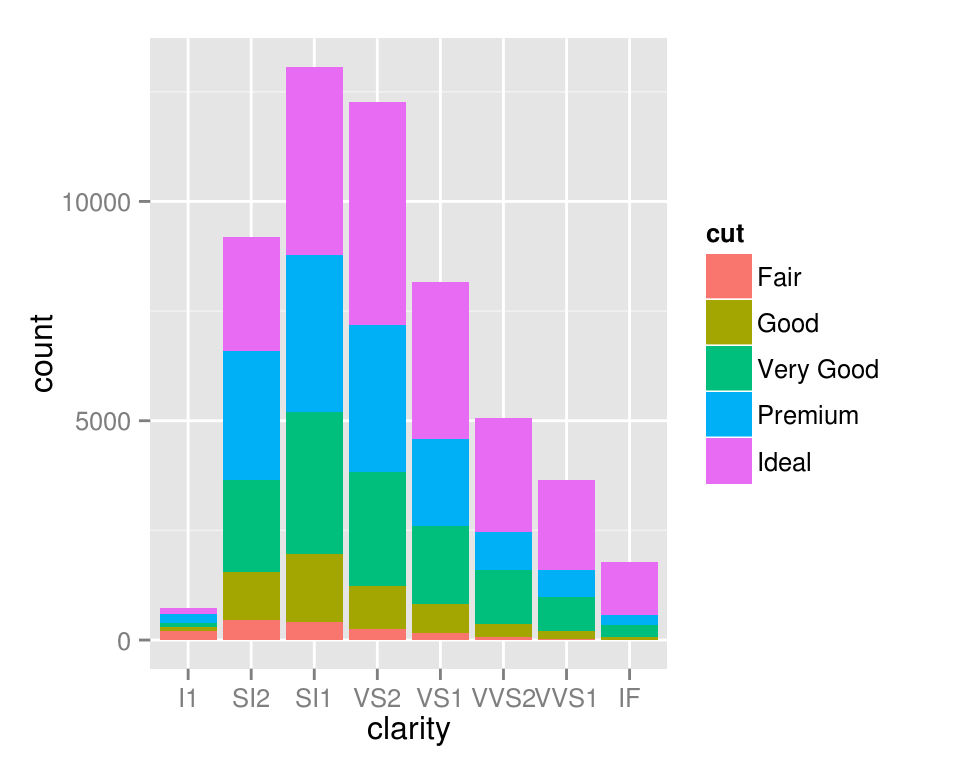

```r
ggplot(diamonds, aes(clarity, fill=cut)) + geom_bar()
```

## Question 5

What is the distribution of cases of typhoid per week? What about per year?  
See `cat(answer5)` and `cat(answer5.1)`

### Density Plot

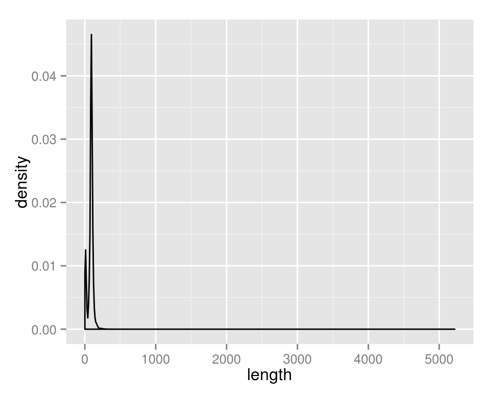

```r
ggplot(movies, aes(length))+geom_density()
```

#### Adjust x and y limits

we need to “zoom in” to get a resonable view create distributions of short vs. non-short movies:

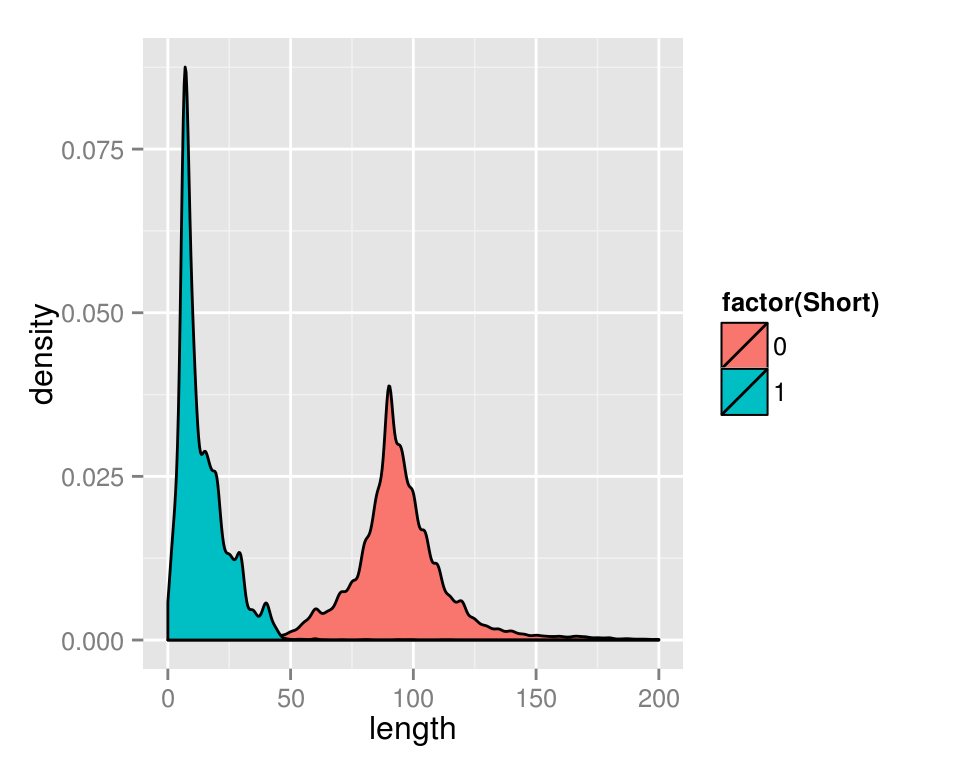

```r
ggplot(movies, aes(x=length,fill=factor(Short)))+geom_density() + xlim(0,200)
```

#### Set transperancy of distro

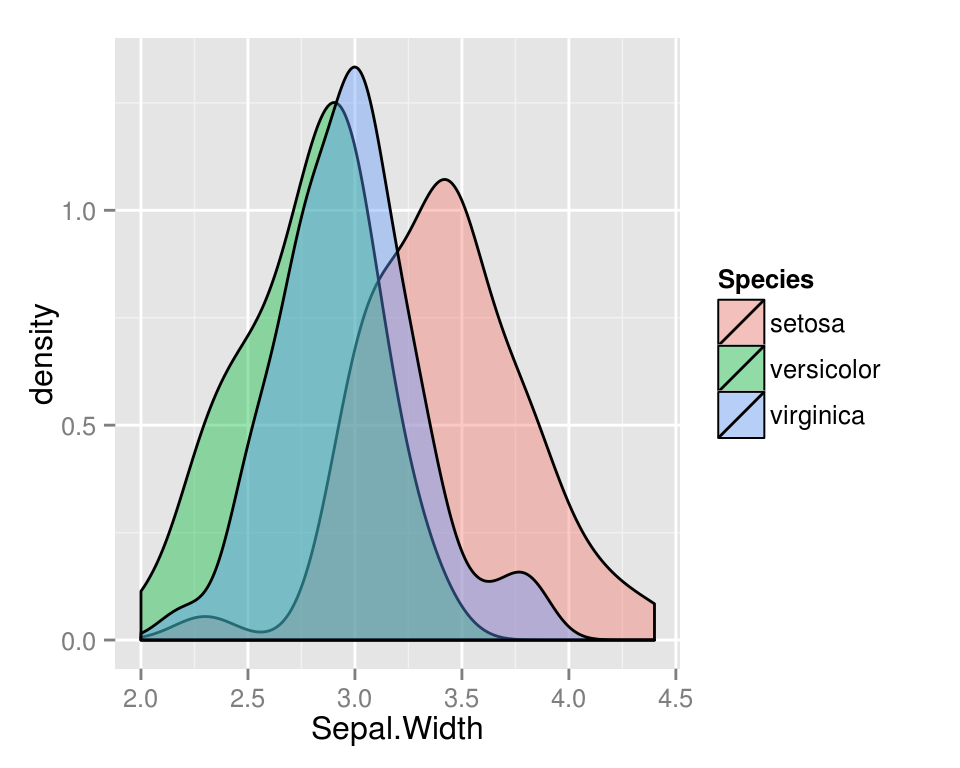

```r
ggplot(iris, aes(x=Sepal.Width,fill=Species))+geom_density(alpha=I(0.4))
```

### Question 6a

High glycosaminoglycans (GAGs) urine levels can progressively damage tissue,  
and high levels are indictitive of inherited disease.Using the `GAGurine` dataset  
from the MASS package, what is the distribution of GAG assay values?  
Check the answer by `cat(answer6a)`.

### Question 6b

What’s the difference in GAG distribution between children under 2 and  
all other children?  
see `cat(hint6b)` for data transform.  
Check the answer by `cat(answer6)`.

## Boxplot

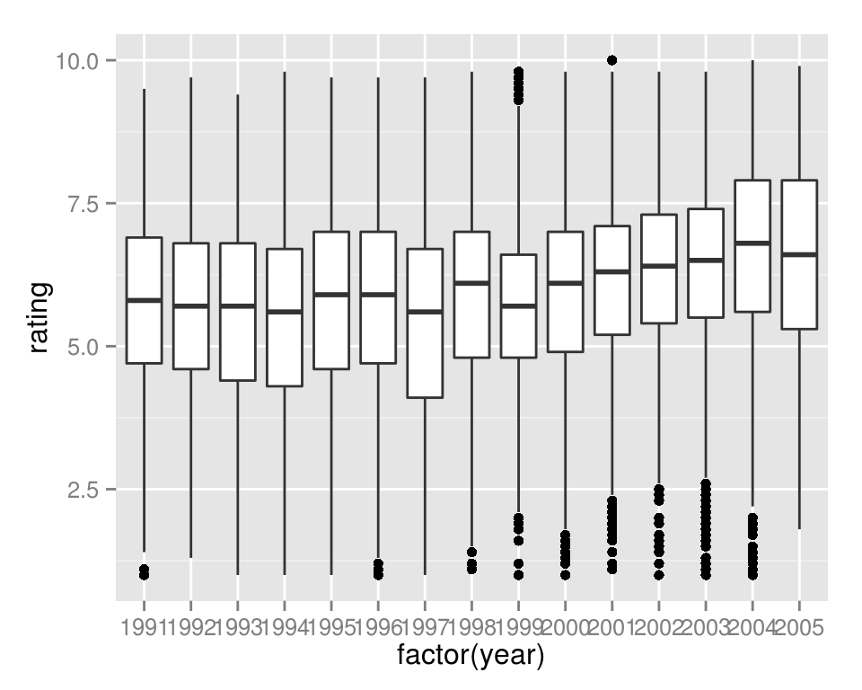

```r
ggplot(movies[movies$year > 1990,],aes(x=factor(year),y=rating)) +
  geom_boxplot()
```

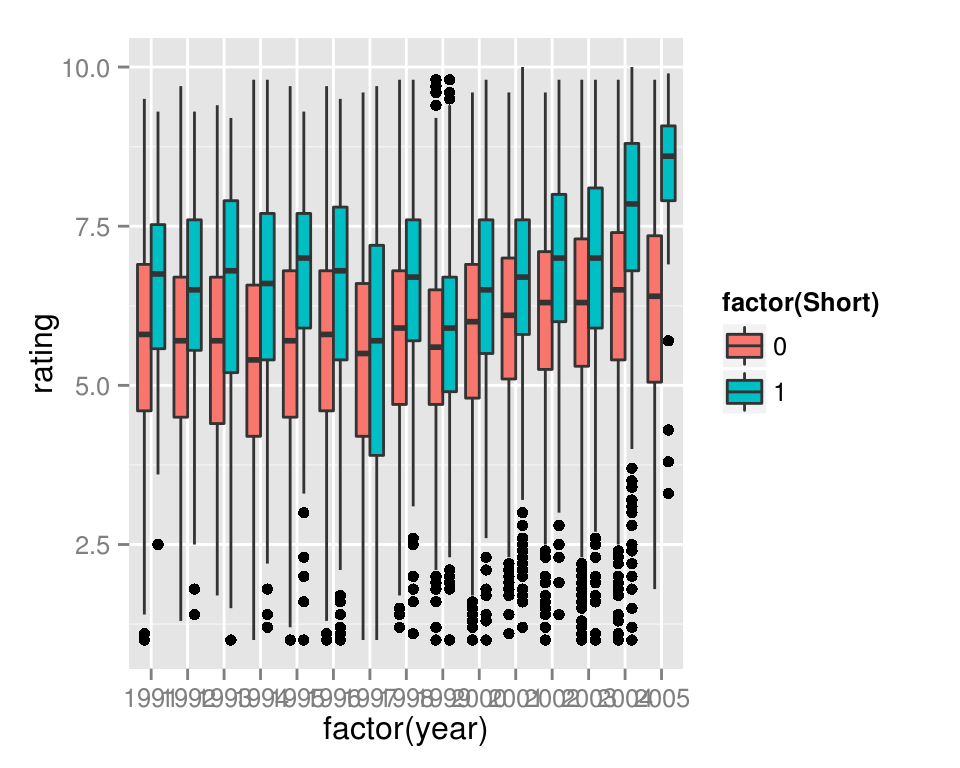

```r
ggplot(movies[movies$year > 1990,],aes(x=factor(year),y=rating,fill=factor(Short))) +
  geom_boxplot()
```

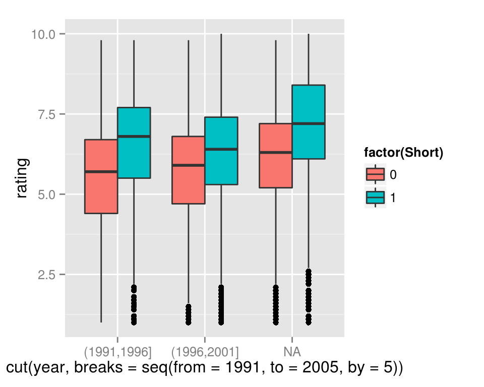

```r
ggplot(movies[movies$year > 1990,],
aes(x=cut(year,breaks=seq(from=1991,to=2005,by=5)),y=rating,fill=factor(Short))) +
geom_boxplot()
```

### Question 7

What is the distribution of GAG assay levels for each age?  
see `cat(hint7)` for data transform.  
Check the answer by `cat(answer7)`.

## Themes

#### Adjust the background color, tick marks, etc

#### store what we have so far to a variable

```r
iris.plot = ggplot(iris,aes(x=Sepal.Width,y=Sepal.Length,color=Species,shape=Species)) +
  geom_point(size=4) +
  geom_point(size=2,color="grey")+
  ggtitle("Measurement of Flowers")+
  xlab("width (cm)")+
  ylab("length (cm)")
```

#### plot stored variable

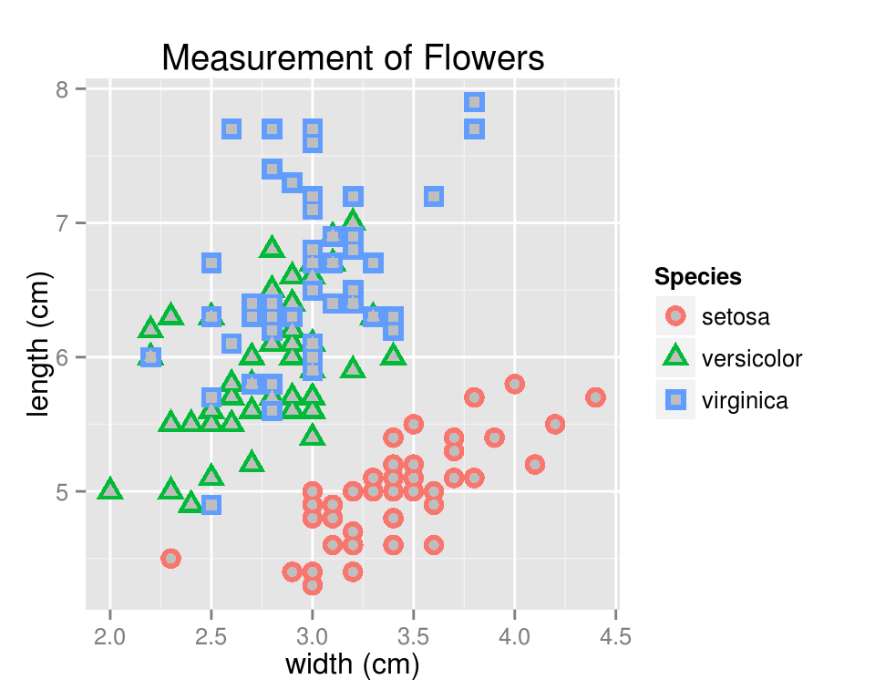

```r
iris.plot
```

#### Change the background to black and white

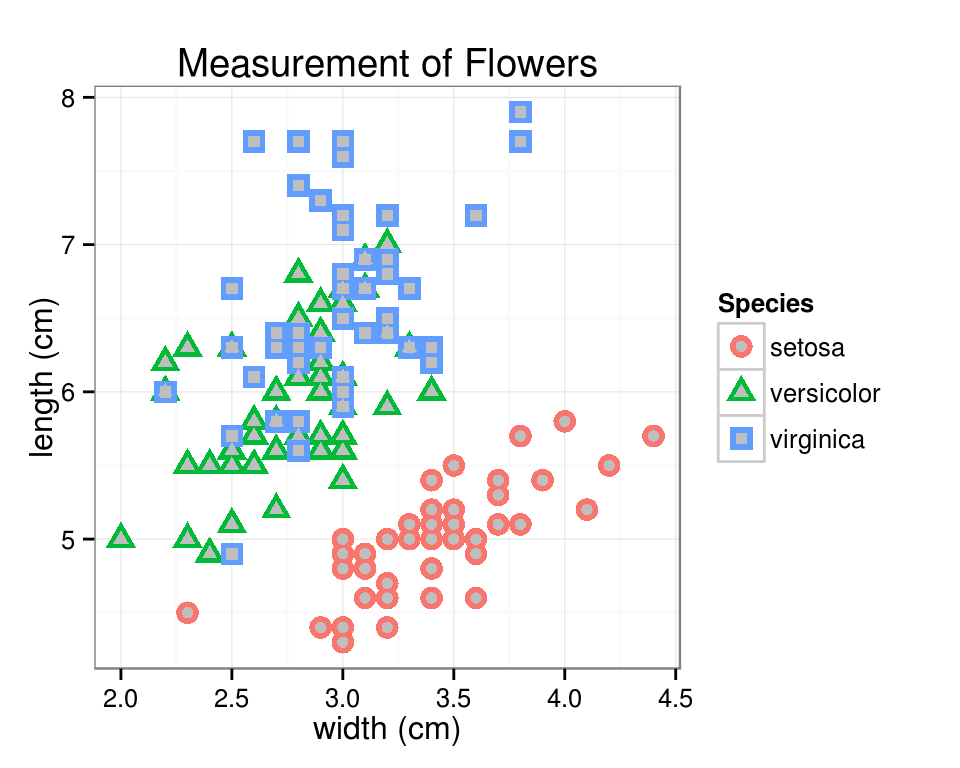

```r
iris.plot + theme_bw()
```

#### Other themes to consider:

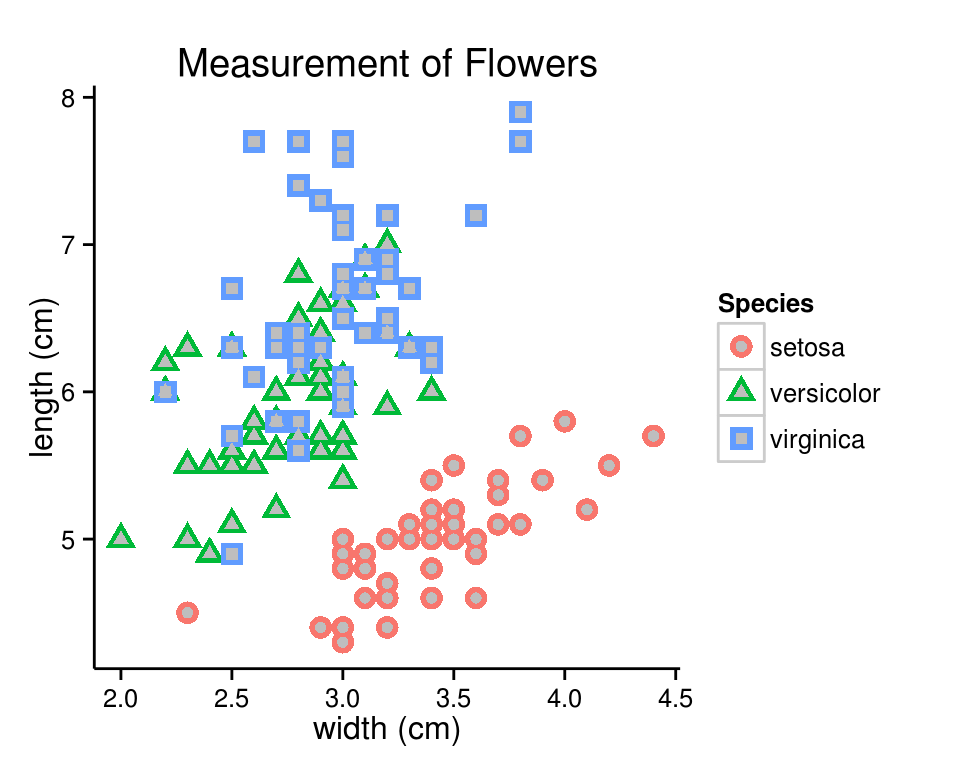

```r
iris.plot + theme_classic()
```

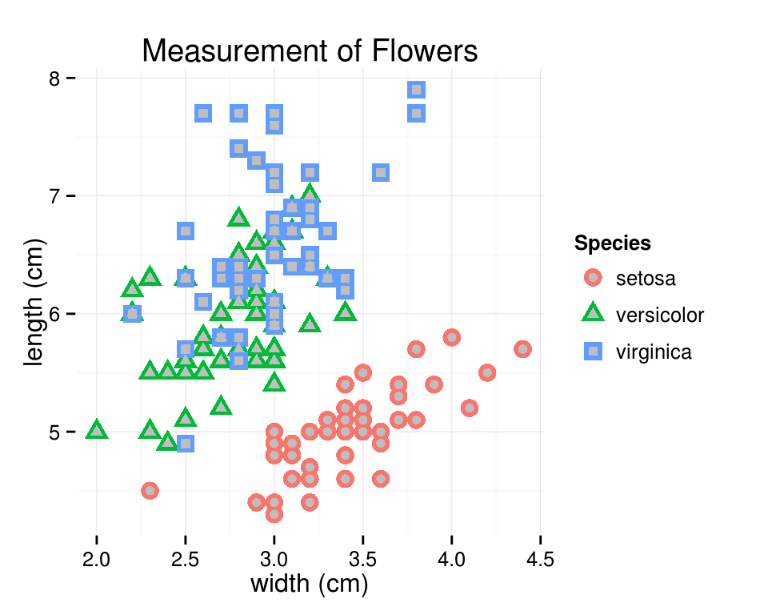

```r
iris.plot + theme_minimal()
```

#### Customize the theme and specify features…

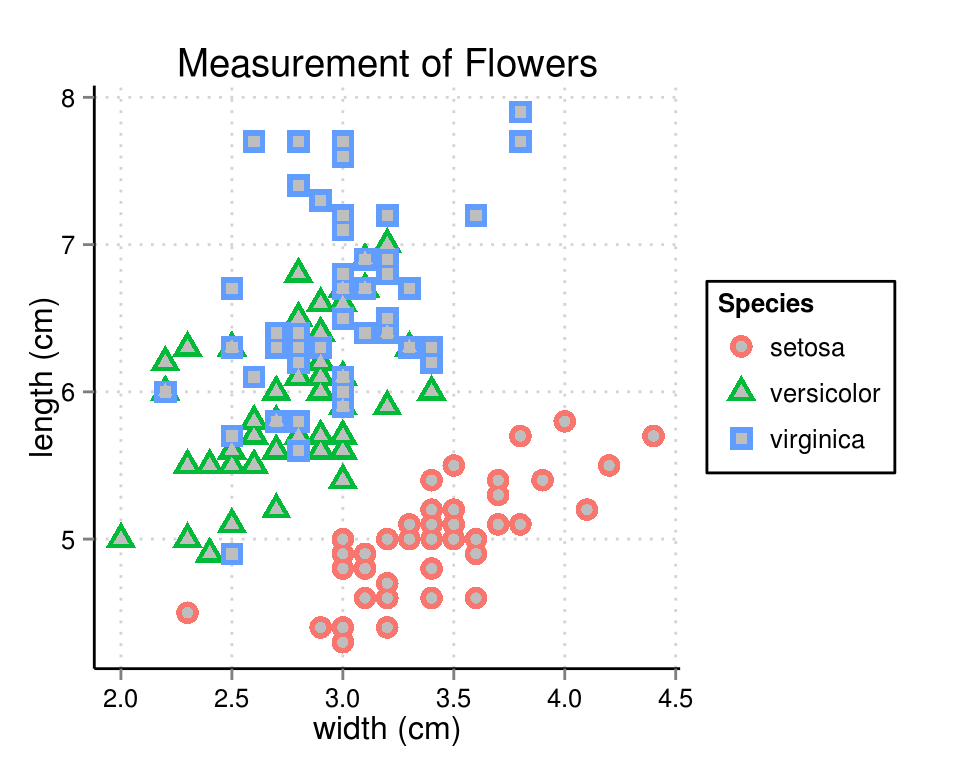

```r
iris.plot +
  theme(plot.background = element_rect(fill = "white"),
        panel.background = element_rect(fill = "white"),
        legend.key = element_rect(fill = "white"),
        legend.background = element_rect(colour = "black"),
        panel.grid.minor = element_blank(),
        panel.grid.major = element_line(colour = "lightgrey", linetype = "dotted"),
        axis.line = element_line(),
        axis.text = element_text(colour = "black"))
```

#### See http://docs.ggplot2.org/current/theme.html for more options

## Question 8

Make the ugliest plot you can. Bonus points for discordant color schemes. Check the answer by `cat(answer8)`.

# Bonus Material

Go through at your own pace, or use as a reference.

## Legend Positioning

what options do we have for the position of the legend? examples borrowed from: http://www.r-bloggers.com/ggplot2-cheatsheet-for-scatterplots/

```r
g1 <- ggplot(mtcars, aes(x = hp, y = mpg)) + geom_point(aes(color=factor(vs)))
```

#### move legend to the inside

```r
g2 <- g1 + theme(legend.position=c(1,1),legend.justification=c(1,1))
```

#### move legend to the bottom

```r
g3 <- g1 + theme(legend.position = "bottom")
```

##### change labels

```r
g4 <- g1 + scale_color_discrete(name ="Engine",
                                labels=c("V-engine", "Straight engine"))
```

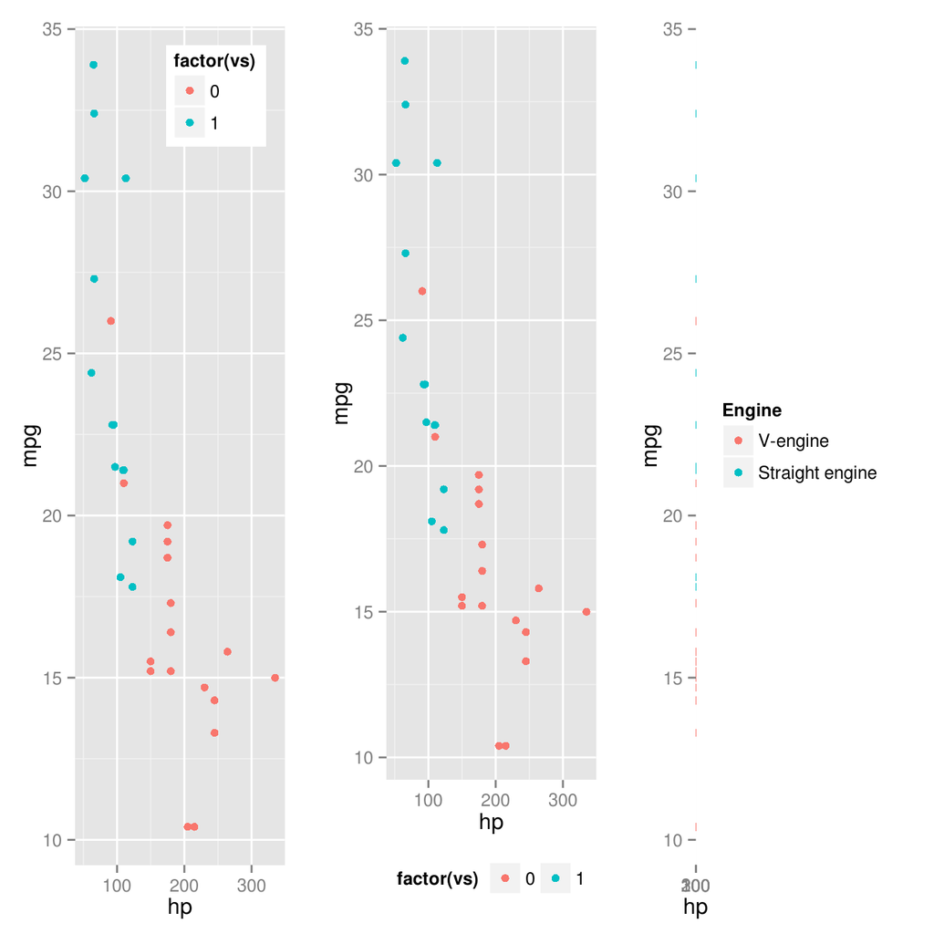

```r
grid.arrange(g2, g3, g4, nrow=1)
```

## Facets

#### Let’s just look at PG, R, and PG-13 rated movies…

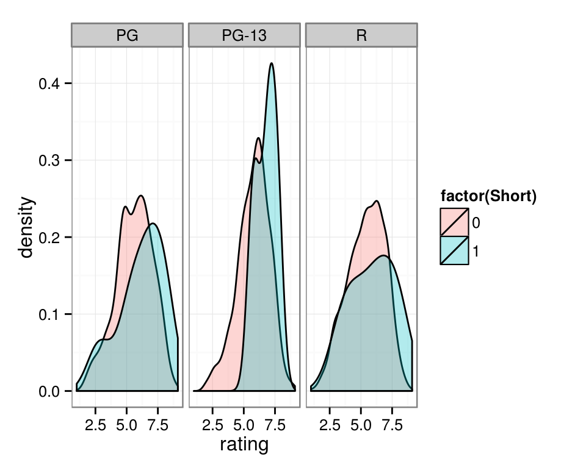

```r
mov.df = movies[as.character(movies$mpaa) %in% c("PG","R","PG-13"),]
mov.df$mpaa = mov.df$mpaa[,drop=TRUE]
ggplot(mov.df,aes(x=rating,fill=factor(Short))) +
  geom_density(alpha=I(0.3)) + theme_bw() +
  facet_wrap(~mpaa)
```

#### seperate movies by decade, rating: view rating distribution

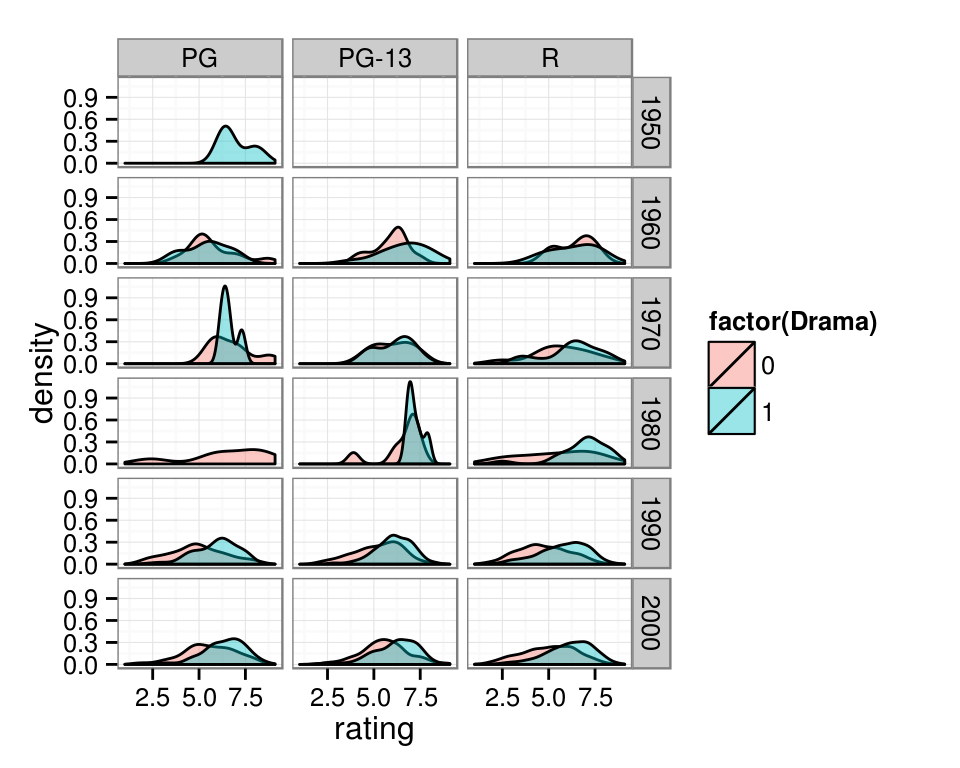

```r
mov.df$decade = mov.df$year %/% 10 * 10
mov50plus.df = mov.df[mov.df$decade >= 1950,]
# facet_grid( y ~ x )
ggplot(mov50plus.df, aes(x=rating,fill=factor(Drama))) +
  geom_density(alpha=I(0.4))+ theme_bw()+
  facet_grid(decade ~ mpaa )
```

## Grids

Set up two different plots of iris data for two species, and view them side by side.

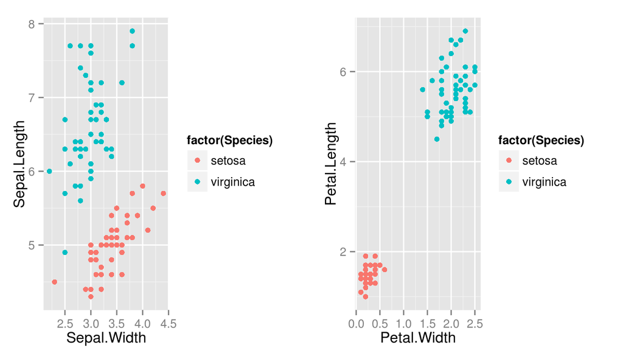

```r
irisSmall.df <- subset(iris, Species != "versicolor")

p1 <- ggplot(irisSmall.df, aes(x= Sepal.Width, y = Sepal.Length)) + geom_point(aes(color=factor(Species)))
p2 <- ggplot(irisSmall.df, aes(x = Petal.Width, y = Petal.Length)) + geom_point(aes(color=factor(Species)))

#' all plots in one row
grid.arrange(p1,p2,nrow=1)
```

## Coordinates

#### coord_flip

flip the coords, easier to read x labels…

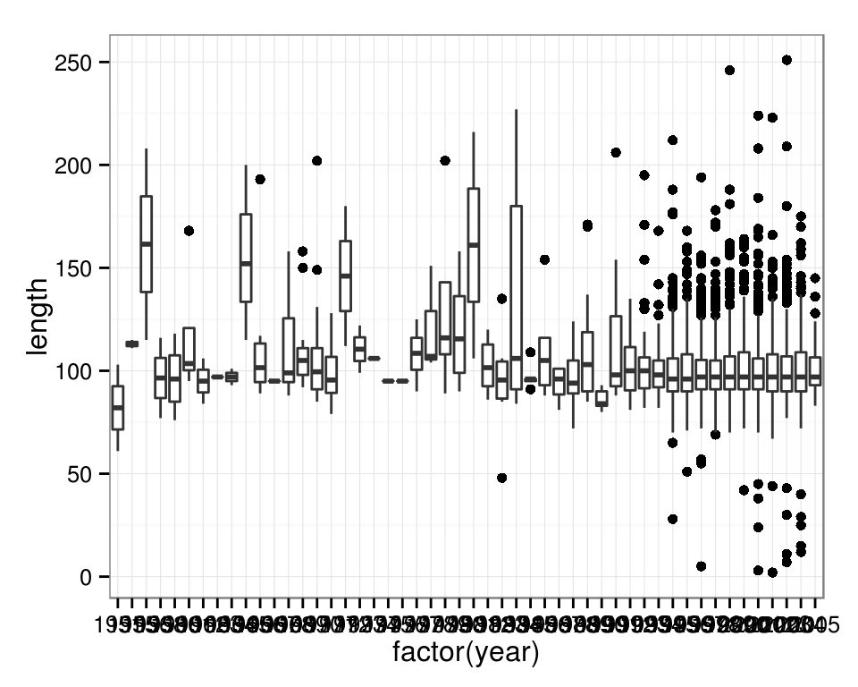

```r
ggplot(mov50plus.df,aes(x=factor(year),y=length))+geom_boxplot()+theme_bw()
```

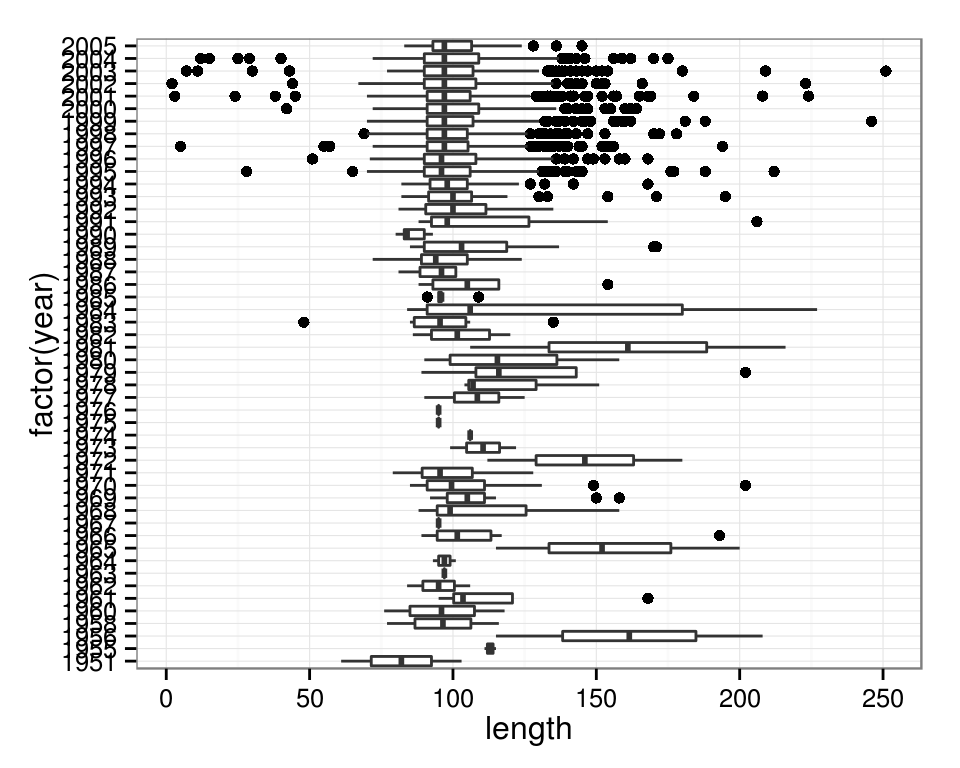

```r
ggplot(mov50plus.df,aes(x=factor(year),y=length))+geom_boxplot()+theme_bw() + coord_flip()
```

## coord_polar

How many teams do baseball players play for?

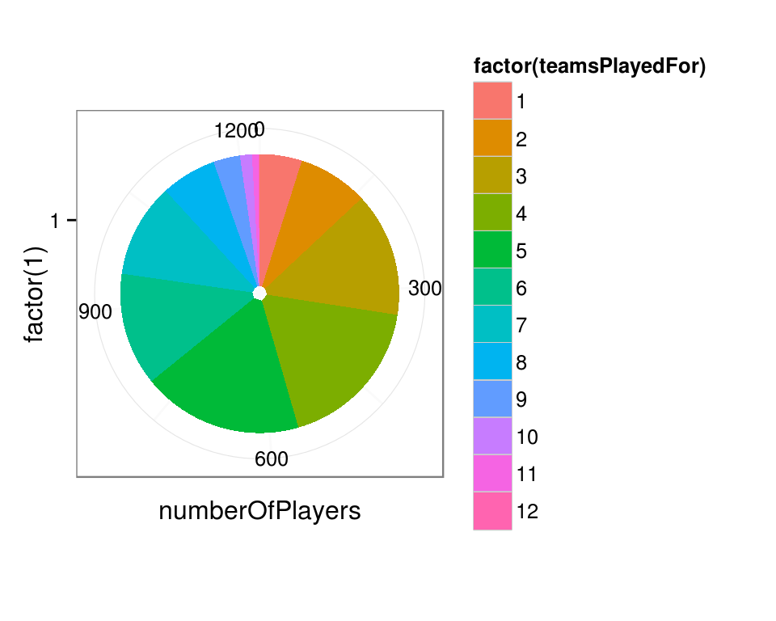

```r
playerTeam.df = ddply(baseball,.(id),function(df)length(unique(df$team)))
teamsPerPlayer.df = as.data.frame(table(playerTeam.df$V1))

colnames(teamsPerPlayer.df) = c("teamsPlayedFor","numberOfPlayers")
teamsPerPlayer.df$teamsPlayedFor = as.numeric(teamsPerPlayer.df$teamsPlayedFor)
ggplot(teamsPerPlayer.df,aes(x=factor(1),y=numberOfPlayers,fill=factor(teamsPlayedFor))) +
  geom_bar(stat="identity") +
  theme_bw() +
  coord_polar(theta="y")
```